# Exam 1

Charles Etuk

2023-03-03

### Question 1

##### 1a) (10 points) Create a data set that includes only cereals that are on shelf 3 and includes only the following variables: name, mfr, type, calories, cups and rating.

```r
Cereal3 <- cereal %>% filter(shelf == "3") %>% select(name, mfr, type, calories, cups, rating)
Cereal3
```

```
##                                      name mfr type calories cups   rating
## 1                               100% Bran   N    C       70 0.33 68.40297
## 2                       100% Natural Bran   Q    C      120 1.00 33.98368
## 3                                All-Bran   K    C       70 0.33 59.42551
## 4               All-Bran with Extra Fiber   K    C       50 0.50 93.70491
## 5                          Almond Delight   R    C      110 0.75 34.38484
## 6                                 Basic 4   G    C      130 0.75 37.03856
## 7                             Bran Flakes   P    C       90 0.67 53.31381
## 8                                Clusters   G    C      110 0.50 40.40021
## 9                      Cracklin' Oat Bran   K    C      110 0.50 40.44877
## 10                                Crispix   K    C      110 1.00 46.89564
## 11                 Crispy Wheat & Raisins   G    C      100 0.75 36.17620
## 12                            Double Chex   R    C      100 0.75 44.33086
## 13 Fruit & Fibre Dates; Walnuts; and Oats   P    C      120 0.67 40.91705
## 14                          Fruitful Bran   K    C      120 0.67 41.01549
```

[output cut: 22 more lines]

##### 1b) (10 points) Using the data from the previous part, create a new variable that is defined as calories divided by cups and sort the data set by this new variable from largest to smallest. Which shelf 3 cereal has the highest calories per cup?

```r
Cereal3 %>% mutate(CalPerCup = calories/cups) %>% arrange(-CalPerCup) %>% head(1)
```

```
##         name mfr type calories cups   rating CalPerCup
## 1 Grape-Nuts   P    C      110 0.25 53.37101       440
```

Grape-Nuts has the highest calories per cup on shelf 3 at 440.

##### 1c) (10 points) Using all the cereal data, merge the full name of the manufacturer onto the data set and then compute the average rating by manufacturer. Which manufacturer has the higest rating? Which manufacturer has the lowest rating? What is the best cereal ever made?

```r
cereal %>% group_by(mfr) %>% summarise(AverageRating = mean(rating)) %>% left_join(cereal_mfr, by = c("mfr" = "mfr")) %>% select(mfr_full, AverageRating) %>% arrange(-AverageRating)
```

```
## # A tibble: 7 × 2
##   mfr_full                    AverageRating
##   <chr>                               <dbl>
## 1 Nabisco                              68.0
## 2 American Home Food Products          54.9
## 3 Kelloggs                             44.0
## 4 Quaker Oats                          42.9
## 5 Post                                 41.7
## 6 Ralston Purina                       41.5
## 7 General Mills                        34.5
```

Nabisco has the highest average rating at 68.0 and General Mills has the lowest rating at 34.5. In my objective opinion, Cinnamon Toast Crunch is the best cereal ever.

##### 1d) (10 points) Create a table where the rows are the full name of the manufacturer and the columns are shelf and the values in each cell of the table are the number of cereals that fall into that category (e.g. the number of cereals manufactured by Nabisco on shelf 2.) (Bonus points: (+2.5 is the columns and rows are correctly orderd. +2.5 if the NAs are replace by 0s))

```r
Shelf1 <- cereal %>% filter(shelf == "1") %>% count(mfr) %>% rename(shelf1 = n)
Shelf2 <- cereal %>% filter(shelf == "2") %>% count(mfr) %>% rename(shelf2 = n)
Shelf3 <- cereal %>% filter(shelf == "3") %>% count(mfr) %>% rename(shelf3 = n)
MfrByShelf <- Shelf1 %>% full_join(Shelf2, by = c("mfr" = "mfr")) %>% full_join(Shelf3, by = c("mfr" = "mfr")) %>% left_join(cereal_mfr, by = c("mfr" = "mfr")) %>% select(mfr_full, shelf1, shelf2, shelf3)
MfrByShelf <- MfrByShelf %>% replace(is.na(MfrByShelf),0)
MfrByShelf
```

```
##                      mfr_full shelf1 shelf2 shelf3
## 1               General Mills      6      7      9
## 2                    Kelloggs      4      7     12
## 3                     Nabisco      3      2      1
## 4                        Post      2      1      6
## 5                 Quaker Oats      1      3      4
## 6              Ralston Purina      4      0      4
## 7 American Home Food Products      0      1      0
```

##### 1e) (10 points) Create a scatterplot with calories per cup on the x-axis and rating on the y-axis with color used to indicate the shelf that the cereal is sold on. Comment on any trends that you notice.

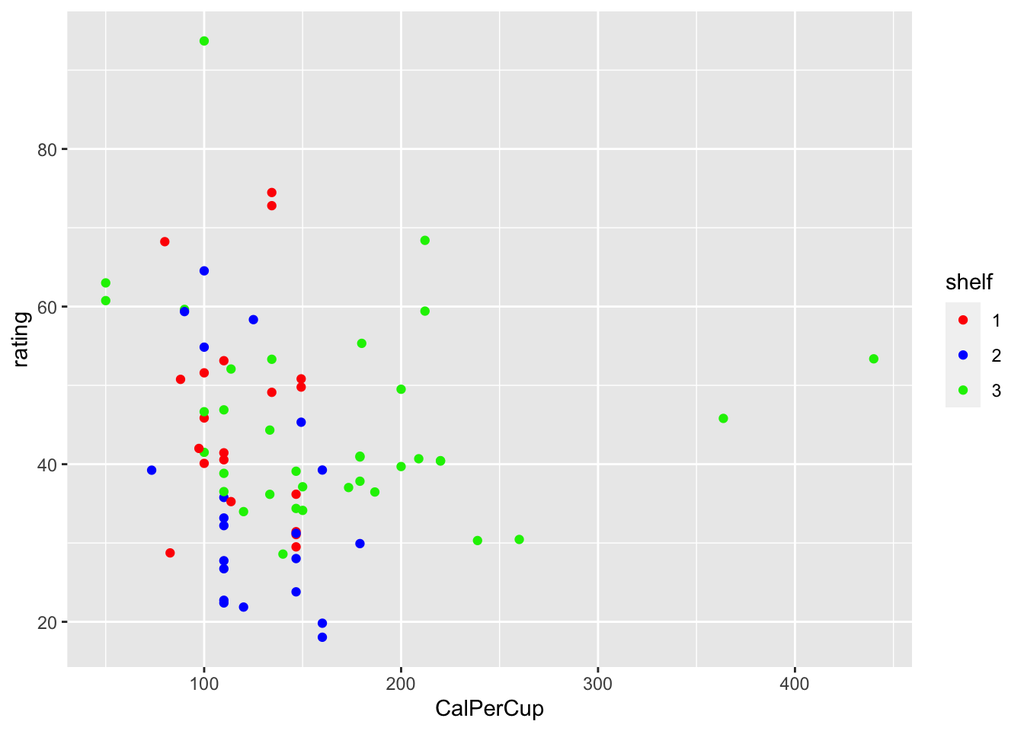

```r
cerealplot <- cereal %>% mutate(CalPerCup = calories/cups)
cerealplot$shelf <- as.factor(cerealplot$shelf)
ggplot(aes(CalPerCup, rating, color = shelf), data = cerealplot) + geom_point() + scale_color_manual(breaks = c("1", "2", "3"), values=c("red", "blue", "green2"))
```

Shelf 3 has a lot more cereals with higher calories per cup in comparison to the other shelves. Every data point from ~180-450 Cal/Cup is on shelf 3.

### Question 2

##### 2a) (10 points) Create a table that has license number and the count of how many tests resulted in ”Fail”. What are the names (i.e. dba name) of the businesses that are in the top ten for most failed inspections?

```r
inspections %>% filter(results == "Fail") %>% mutate(Fail = 1) %>% group_by(license_number, dba_name) %>% summarise(FailCounts = sum(Fail)) %>% arrange(-FailCounts) %>% head(10)
```

```
## # A tibble: 10 × 3
## # Groups:   license_number [10]
##    license_number dba_name                    FailCounts
##             <int> <chr>                            <dbl>
##  1        1095992 LAS ISLAS MARIAS                    19
##  2          39623 LUMES PANCAKE HOUSE                 17
##  3        1909713 IYANZE                              17
##  4        1893655 MARISCOS LAS ISLITAS                16
##  5        1144034 SILVER'S SEAFOOD RESTAURANT         15
##  6          25152 JOSEPHINE'S COOKIN'                 14
##  7          39084 PIZZA CAPRI                         14
##  8          60184 TAQUERIA EL RANCHITO                14
##  9        1042888 DEVON MARKET                        14
## 10        1299747 NICKY'S CHINESE FOOD                14
```

The businesses that are top 10 in failed inspections are Las Islans Marias, Lumes Pancake House, Iyanze, Mariscos Las Islitas, Silver’s Seafood Restaurant, Josephine’s Cookin’, Pizza Capri, Taqueria El Ranchito, Devon Market and Nicky’s Chinese Food.

##### 2b) (10 points) What is the pass rate by inspection type?

```r
inspectionsrate <- inspections %>% mutate(Pass = case_when(results == 'Pass' ~ 1, results == 'Fail' ~ 0, results == 'Pass w/ Conditions' ~ 1)) %>% mutate(Fail = case_when(results == 'Pass' ~ 0, results == 'Fail' ~ 1, results == 'Pass w/ Conditions' ~ 0))
inspectionsrate %>% group_by(inspection_type) %>% summarise(PassRate = sum(Pass)/(sum(Fail)+sum(Pass)))
```

```
## # A tibble: 3 × 2
##   inspection_type PassRate
##   <chr>              <dbl>
## 1 canvass            0.806
## 2 complaint          0.730
## 3 license            0.692
```

Canvass inspections have a pass rate of 80.6%, complaints have a pass rate of 73%, and licenses have a pass rate of 69.2%.

##### 2c) (10 points)How many businesses (defined by license number) have ever failed an inspection?

```r
inspections %>% filter(results == "Fail") %>% count(license_number) %>% nrow()
```

```
## [1] 12995
```

##### 2d) (10 points) Using only businesses in with zip code equal to 60660 or 60626 (i.e. Rogers Park and Edgewater), count the number of inspections that each license number has had. Then plot side by side boxplots of the number of inspections stratified by zip code.

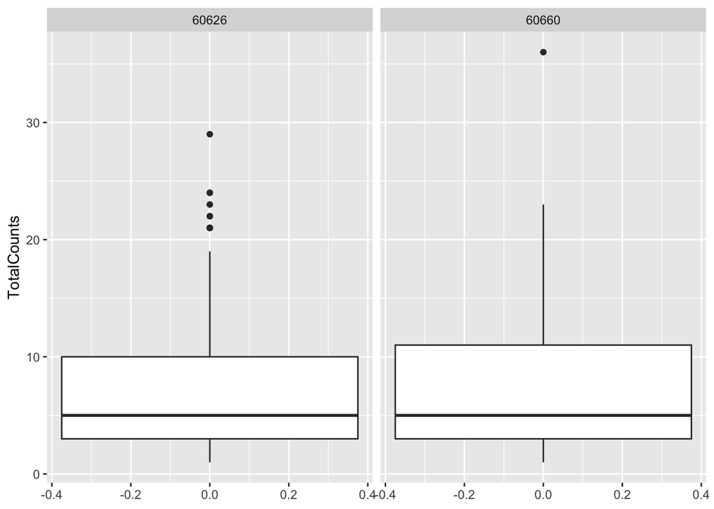

```r
RPEWinspections <- inspections %>% filter(zip == 60660 | zip == 60626) %>% mutate(counter = 1)
RPEWinspectionsZip <- RPEWinspections %>% group_by(license_number) %>% summarise(zipcode = mean(zip), TotalCounts = sum(counter))
ggplot(aes(y = TotalCounts), data = RPEWinspectionsZip) + geom_boxplot() + facet_wrap(~zipcode)
```

##### 2e) (10 points) What is the restaurant with the largest number of inspections that has passed (do NOT include “passed with conditions”) ALL of their inspections and how many inspections did they have? That is which restaurant had the most inspections without any failure?

```r
restaurantinspections <- inspections %>% filter(facility_type == "restaurant")
allpassed <- restaurantinspections %>% mutate(PorF = case_when(results == 'Pass' ~ 1, results == 'Fail' ~ 0, results == 'Pass w/ Conditions' ~ 0)) %>% mutate(counter = 1) %>% group_by(license_number, dba_name) %>% summarise(PassTotal = (sum(PorF)), TotalInspections = sum(counter))
allpassed %>% filter(PassTotal == TotalInspections) %>% arrange(-PassTotal) %>% head(5)
```

```
## # A tibble: 5 × 4
## # Groups:   license_number [5]
##   license_number dba_name               PassTotal TotalInspections
##            <int> <chr>                      <dbl>            <dbl>
## 1        1492416 SUBWAY                        17               17
## 2        1197659 MANNY'S CAFE MIDWAY           16               16
## 3        1845262 WOW BAO                       16               16
## 4        1140054 LUIGI STEFANI PIZZERIA        15               15
## 5        1142106 PEGASUS ON THE FLY            15               15
```

```r
allpassed2 <- restaurantinspections %>% mutate(PorF = case_when(results == 'Pass' ~ 1, results == 'Fail' ~ 0, results == 'Pass w/ Conditions' ~ 0)) %>% mutate(counter = 1) %>% group_by(dba_name) %>% summarise(PassTotal = (sum(PorF)), TotalInspections = sum(counter))
allpassed2 %>% filter(PassTotal == TotalInspections) %>% arrange(-PassTotal) %>% head(5)
```

```
## # A tibble: 5 × 3
##   dba_name                             PassTotal TotalInspections
##   <chr>                                    <dbl>            <dbl>
## 1 MANNY'S CAFE MIDWAY                         16               16
## 2 HARRY CARAY'S SEVENTH INNING STRETCH        15               15
## 3 LUIGI STEFANI PIZZERIA                      15               15
## 4 MILLERS PUB                                 15               15
## 5 TAYLOR STREET MARKET                        15               15
```

For all individual restaurants with 100% pass inspection rate, the Subway with the license number 1492416 has the highest total with 17/17 passed inspections. For all businesses (defined by dba_name) with 100% pass inspection rate, Manny’s Cafe Midway has the highest total with 16/16 inspections.